# Data Sufficiency for the Proposed Bonytail IPM (Sound Science LLC)

Annual-occasion detection, age/origin stage, and event-timing diagnostics for IPCA Ponds 2, 5, 6

Author

Marsh & Associates

Published

September 21, 2026

## Purpose and how to read this report

This report asks whether the IPCA Ponds 2, 5, and 6 Bonytail data support the structure **Sound Science LLC has proposed** for a bonytail integrated population model (IPM) — an annualized, Bayesian state-space model with CJS-style mark-recapture, age/size-based juvenile stages, a per-pond stocked-vs-wild-hatched origin effect, and environmental covariates on survival and reproduction (`documents/BONY Proposed IPM - Model Description 9-16-26.docx`, summarized in `documents/BONY_Proposed_IPM_Summary.md`).

This is a self-contained, reproducible document: every table and figure is computed directly from `data/ReportingData.RData` (raw PIT-tag, netting, and stocking records) and the hand-maintained `data/BWDieOffEvents.csv` file. No survival, growth, or population model is fit here — the goal is only to characterize the raw data available to inform the proposed IPM’s structure, so the underlying tables and CSV inputs can be shared and checked independently of any other model output.

Scope is the off-channel component only — **IPCA Ponds 2, 5, 6**, the only sites this project holds Bonytail data for. The open-water CJS component and Cibola High Levee Pond are outside this project’s data and are not addressed.

## Annual-occasion detection sufficiency

The proposed model uses an **annual** time step. This section collapses `StudyBWContacts` to one Oct–Apr occasion per fiscal year (FY) per pond — the coarsest reasonable annualization, matching this project’s existing Jan–Feb/Oct–Apr mark-recapture convention — and asks how much information a single annual occasion carries, compared to the up to 7 months per season (Oct–Apr) over which PIT-scan contacts are actually recorded in the raw data.

Annual (Oct–Apr) occasion detection summary, one row per pond × FY

| Pond | FY | Known alive (Oct–Apr) | Detected this FY | Annual detection rate | Detected again next FY | Sufficient? |
| --- | --- | --- | --- | --- | --- | --- |
| Pond 2 | 2017 | 299 | 144 | 0.48 | 92 | TRUE |
| Pond 2 | 2018 | 277 | 248 | 0.90 | 27 | TRUE |
| Pond 2 | 2019 | 96 | 62 | 0.65 | 14 | TRUE |
| Pond 2 | 2020 | 219 | 161 | 0.74 | 21 | TRUE |
| Pond 2 | 2021 | 61 | 47 | 0.77 | 11 | TRUE |
| Pond 2 | 2022 | 124 | 99 | 0.80 | 0 | FALSE |
| Pond 2 | 2023 | 300 | 294 | 0.98 | 233 | TRUE |
| Pond 2 | 2024 | 537 | 489 | 0.91 | 138 | TRUE |
| Pond 2 | 2025 | 140 | 140 | 1.00 | 9 | TRUE |
| Pond 5 | 2017 | 300 | 156 | 0.52 | 147 | TRUE |
| Pond 5 | 2018 | 280 | 280 | 1.00 | 24 | TRUE |
| Pond 5 | 2019 | 49 | 48 | 0.98 | 39 | TRUE |
| Pond 5 | 2020 | 150 | 143 | 0.95 | 0 | FALSE |
| Pond 5 | 2021 | 1 | 1 | 1.00 | 1 | FALSE |
| Pond 5 | 2022 | 301 | 271 | 0.90 | 229 | TRUE |
| Pond 5 | 2023 | 256 | 253 | 0.99 | 164 | TRUE |
| Pond 5 | 2024 | 175 | 173 | 0.99 | 101 | TRUE |
| Pond 5 | 2025 | 101 | 101 | 1.00 | 47 | TRUE |
| Pond 6 | 2017 | 300 | 183 | 0.61 | 166 | TRUE |
| Pond 6 | 2018 | 263 | 260 | 0.99 | 128 | TRUE |
| Pond 6 | 2019 | 147 | 142 | 0.97 | 59 | TRUE |
| Pond 6 | 2020 | 141 | 138 | 0.98 | 73 | TRUE |
| Pond 6 | 2021 | 149 | 136 | 0.91 | 68 | TRUE |
| Pond 6 | 2022 | 172 | 160 | 0.93 | 101 | TRUE |
| Pond 6 | 2023 | 195 | 192 | 0.98 | 101 | TRUE |
| Pond 6 | 2024 | 161 | 157 | 0.98 | 120 | TRUE |
| Pond 6 | 2025 | 120 | 120 | 1.00 | 68 | TRUE |

“Sufficient” here uses a low bar (≥15 fish known alive, ≥5 detected again the following FY) — the minimum for an annual survival/detection pair to be estimated from more than a handful of observations, not a precision target. `recap_next_fy` is the direct annual analogue of a CJS mark-recapture count between two consecutive occasions; a single annual occasion collapses what the raw PIT-scan record actually resolves at weekly-to-monthly grain within each Oct–Apr season, so an annual-step CJS necessarily discards most of the within-season detection information present in the data.

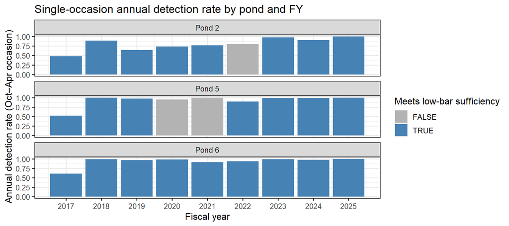

## Die-off timing vs. annual-occasion boundaries

The two confirmed GIEL die-offs (IP5 2020, IP2 2022) are documented month-by-month in `data/BWDieOffEvents.csv` and land mid-fiscal-year, not at FY boundaries. A single annual survival parameter for the FY containing a crash necessarily averages several full-survival months together with the acute event, diluting the fitted magnitude of the crash relative to the true monthly-scale mortality rate — a general problem for any annual-step model asked to represent an event that only occupies part of a year.

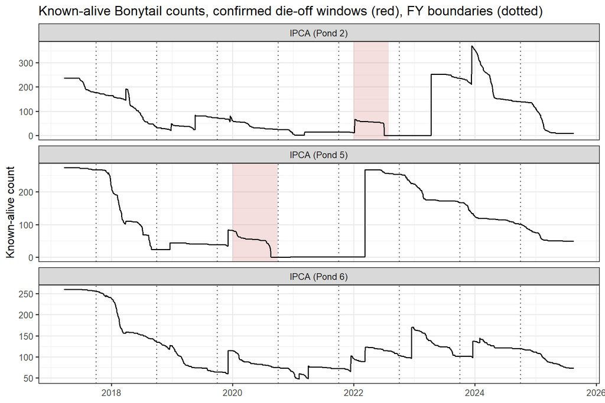

## Age/origin stage sufficiency

The proposed model splits juvenile survival into age-0/age-1 annual steps and estimates a per-pond stocked-vs-wild-hatched origin effect. Both require enough wild-hatched (net-captured, not stocked) juveniles tagged and later re-encountered. The table below is computed live from `StudyBWAnalysis`.

Wild-hatched (net-captured, <250mm TL) juveniles tagged by pond and FY

| Pond | FY | Wild-hatched tagged | Recontacted ≥ 1 yr | Prop. recontacted | Median TL (mm) | SD TL (mm) | Sufficient for origin/age split? |
| --- | --- | --- | --- | --- | --- | --- | --- |
| Pond 2 | 2017 | 0 | 0 | NA | NA | NA | FALSE |
| Pond 2 | 2018 | 100 | 9 | 0.09 | 142.0 | 31.0 | FALSE |
| Pond 2 | 2019 | 155 | 20 | 0.13 | 142.0 | 32.0 | TRUE |
| Pond 2 | 2020 | 71 | 10 | 0.14 | 179.0 | 34.9 | TRUE |
| Pond 2 | 2021 | 35 | 3 | 0.09 | 168.0 | 31.5 | FALSE |
| Pond 2 | 2022 | 58 | 0 | 0.00 | 138.5 | 45.4 | FALSE |
| Pond 2 | 2023 | 0 | 0 | NA | NA | NA | FALSE |
| Pond 2 | 2024 | 301 | 47 | 0.16 | 129.0 | 28.7 | TRUE |
| Pond 2 | 2025 | 0 | 0 | NA | NA | NA | FALSE |
| Pond 5 | 2017 | 0 | 0 | NA | NA | NA | FALSE |
| Pond 5 | 2018 | 11 | 9 | 0.82 | 221.0 | 23.7 | FALSE |
| Pond 5 | 2019 | 12 | 7 | 0.58 | 230.5 | 11.2 | FALSE |
| Pond 5 | 2020 | 62 | 0 | 0.00 | 227.5 | 29.2 | FALSE |
| Pond 5 | 2021 | 0 | 0 | NA | NA | NA | FALSE |
| Pond 5 | 2022 | 0 | 0 | NA | NA | NA | FALSE |
| Pond 5 | 2023 | 1 | 0 | 0.00 | 141.0 | NA | FALSE |
| Pond 5 | 2024 | 1 | 0 | 0.00 | 207.0 | NA | FALSE |
| Pond 5 | 2025 | 0 | 0 | NA | NA | NA | FALSE |
| Pond 6 | 2017 | 0 | 0 | NA | NA | NA | FALSE |
| Pond 6 | 2018 | 5 | 3 | 0.60 | 210.0 | 32.2 | FALSE |
| Pond 6 | 2019 | 10 | 7 | 0.70 | 190.5 | 27.7 | FALSE |
| Pond 6 | 2020 | 7 | 6 | 0.86 | 200.0 | 49.2 | FALSE |
| Pond 6 | 2021 | 5 | 2 | 0.40 | 203.0 | 62.8 | FALSE |
| Pond 6 | 2022 | 36 | 24 | 0.67 | 230.5 | 27.8 | TRUE |
| Pond 6 | 2023 | 15 | 11 | 0.73 | 170.0 | 26.8 | TRUE |
| Pond 6 | 2024 | 7 | 4 | 0.57 | 190.0 | 51.5 | FALSE |
| Pond 6 | 2025 | 0 | 0 | NA | NA | NA | FALSE |

5 of 27 pond-years (19%) clear even this low bar (≥15 tagged, ≥10 recontacted ≥1 yr later).

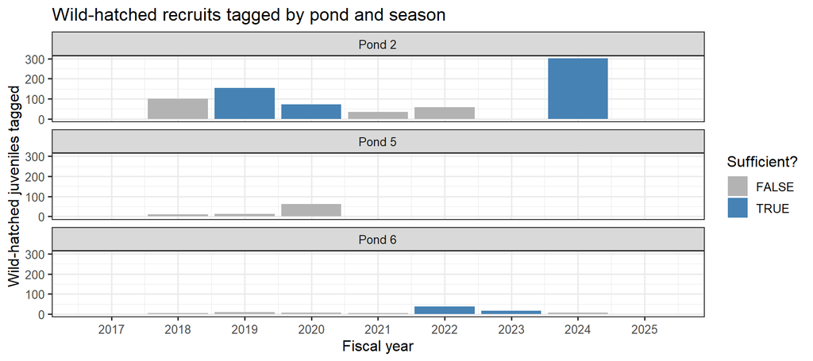

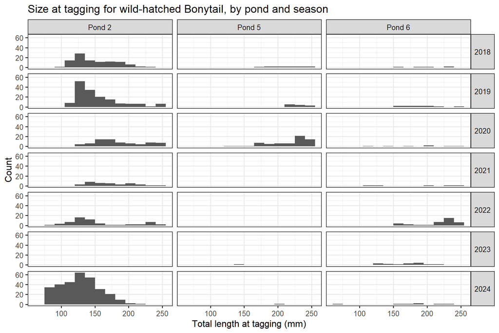

## Growth-curve identifiability for hatch-year assignment

The proposed age-based structure back-calculates each wild-hatched recruit’s hatch year from length via a single fitted von Bertalanffy growth curve. This project has already fit that curve, under three different data-pooling choices, in `model/GIEL_GrowthTrackComparison.R` (full detail in `model/GIEL_GrowthTrackComparison_Summary.md`). In every version, the fitted asymptotic size (`Linf`) collapsed **below** the largest Bonytail actually measured in these ponds — a classic symptom of too few recaptures near the adult size ceiling, not a bug in any one fit. The figure below (reproduced from that completed model, not re-fit here) shows how much the resulting probability-of-maturation curves diverge across model choices, particularly at smaller sizes — the same instability that would propagate into any hatch-year back-calculation.

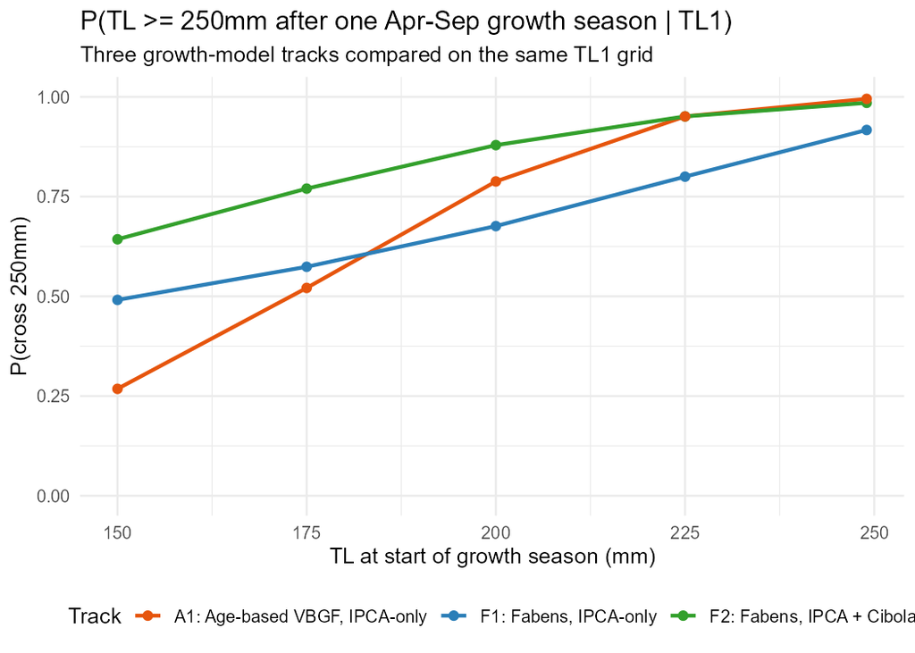

Existing GIEL growth-track model comparison (reused from `model/GIEL_GrowthTrackComparison.R`)

**Practical consequence:** even within the pond-years flagged as “sufficient” above, any age-0/age-1 split or hatch-year assignment inherits this curve’s uncertainty, which is worst for exactly the smaller, more numerous wild-hatched fish that dominate the tagged sample.

## Origin composition per pond-year

For a per-pond origin effect (stocked vs. wild-hatched) to be estimable at all, a pond-season needs *both* origins present in meaningful numbers. This extends the wild-hatched-only table above to include stocked fish for context.

Stocked vs. wild-hatched Bonytail tagged, by pond and FY

| Pond | FY | Stocked tagged | Wild-hatched tagged | Both origins present? |
| --- | --- | --- | --- | --- |
| Pond 2 | 2017 | 299 | 0 | FALSE |
| Pond 2 | 2018 | 0 | 100 | FALSE |
| Pond 2 | 2019 | 0 | 164 | FALSE |
| Pond 2 | 2020 | 0 | 146 | FALSE |
| Pond 2 | 2021 | 0 | 36 | FALSE |
| Pond 2 | 2022 | 0 | 110 | FALSE |
| Pond 2 | 2023 | 300 | 0 | FALSE |
| Pond 2 | 2024 | 0 | 301 | FALSE |
| Pond 2 | 2025 | 0 | 0 | FALSE |
| Pond 5 | 2017 | 300 | 0 | FALSE |
| Pond 5 | 2018 | 0 | 12 | FALSE |
| Pond 5 | 2019 | 0 | 25 | FALSE |
| Pond 5 | 2020 | 0 | 111 | FALSE |
| Pond 5 | 2021 | 0 | 1 | FALSE |
| Pond 5 | 2022 | 300 | 0 | FALSE |
| Pond 5 | 2023 | 0 | 2 | FALSE |
| Pond 5 | 2024 | 0 | 8 | FALSE |
| Pond 5 | 2025 | 0 | 0 | FALSE |
| Pond 6 | 2017 | 300 | 0 | FALSE |
| Pond 6 | 2018 | 0 | 8 | FALSE |
| Pond 6 | 2019 | 0 | 12 | FALSE |
| Pond 6 | 2020 | 0 | 77 | FALSE |
| Pond 6 | 2021 | 0 | 74 | FALSE |
| Pond 6 | 2022 | 0 | 100 | FALSE |
| Pond 6 | 2023 | 0 | 92 | FALSE |
| Pond 6 | 2024 | 0 | 60 | FALSE |
| Pond 6 | 2025 | 0 | 0 | FALSE |

Only 0 of 27 pond-years have any stocked and any wild-hatched fish tagged in the same season — most pond-years are effectively single-origin, meaning an origin effect is identified mainly by *between*-season, not *within*-season, contrast, and is confounded with whatever season-to-season variation (including the two known crashes) coincides with a change in which origin dominates.

## Reproduction (F) data availability

The proposed model estimates reproduction (F) from parentage assignment of genotyped larvae/YOY against a near-complete genotyped adult pool. This project’s genetics pipeline currently has parentage data only for Yuma Cove and IPCA Pond 1 **Razorback Sucker** — there is no GIEL parentage join in this project’s data. A separate University of New Mexico dataset with some bonytail parentage data exists (a coarse pond/year/stage/N summary, `data/UNM_GIEL_ParentageSampling.csv`), but its coverage of IP2/5/6 specifically, its temporal span, and whether it is available at the individual-assignment level (vs. summary statistics only) are open questions this report cannot resolve. No new data pull is attempted here — this is a documented capability gap, not a data-sufficiency result this report can compute.

## Environmental covariates

Dissolved oxygen, temperature, and water-level series are not currently collected or stored for any IPCA pond in this project, but that is a data-collection timeline issue, not a critique — Sound Science’s proposal is expected to supply this data. The substantive question this section asks instead is whether *any* covariate model (environmental or otherwise, pooled across ponds per the proposal’s own §1.6 design) could be identified from how these three ponds have actually been managed and monitored, independent of whether the covariate series themselves are good.

**Pond × year events are not crossed.** A covariate model with slopes shared across ponds and intercepts/year-effects specific to each needs a pond × year design where “what happened” isn’t perfectly aliased with “which pond, which year.” The table below (built from data already loaded in this report — stocking events in `StudyBWAnalysis`, confirmed die-off windows in `data/BWDieOffEvents.csv`, and the known-alive counts computed in the Annual-occasion section above) shows the opposite: each pond’s major events land in different, pond-specific years.

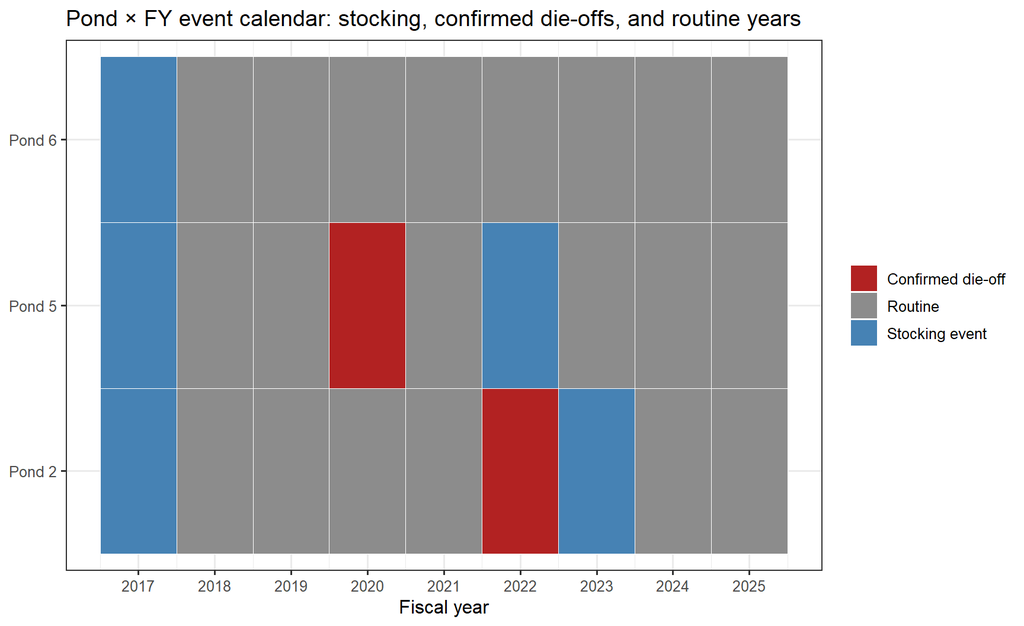

**Variability already visible in the raw contact record, with no obvious smooth pattern.** As a data-only (not model-fitted) check, the chunk below computes a simple apparent-retention proxy for each non-event pond-season directly from `StudyBWContacts`: of the fish detected at all within a given FY’s Oct–Apr window, what fraction are detected again in the following FY’s Oct–Apr window. This is **not** a survival estimate — it mixes true mortality with detection probability and emigration/transfer — but it is a fully transparent, reproducible summary of how much year-to-year change the raw data already show, computed with no model of any kind.

Non-event pond-seasons: fraction of fish detected in one FY also detected the next

| Pond | FY | Detected this FY | Also detected next FY | Apparent retention |
| --- | --- | --- | --- | --- |
| Pond 2 | 2017 | 144 | 92 | 0.64 |
| Pond 5 | 2017 | 156 | 147 | 0.94 |
| Pond 6 | 2017 | 183 | 166 | 0.91 |
| Pond 2 | 2018 | 248 | 27 | 0.11 |
| Pond 5 | 2018 | 280 | 24 | 0.09 |
| Pond 6 | 2018 | 260 | 128 | 0.49 |
| Pond 2 | 2019 | 62 | 14 | 0.23 |
| Pond 5 | 2019 | 48 | 39 | 0.81 |
| Pond 6 | 2019 | 142 | 59 | 0.42 |
| Pond 2 | 2020 | 161 | 21 | 0.13 |
| Pond 6 | 2020 | 138 | 73 | 0.53 |
| Pond 2 | 2021 | 47 | 11 | 0.23 |
| Pond 6 | 2021 | 136 | 68 | 0.50 |
| Pond 5 | 2022 | 271 | 229 | 0.85 |
| Pond 6 | 2022 | 160 | 101 | 0.63 |
| Pond 2 | 2023 | 294 | 233 | 0.79 |
| Pond 5 | 2023 | 253 | 164 | 0.65 |
| Pond 6 | 2023 | 192 | 101 | 0.53 |
| Pond 2 | 2024 | 489 | 138 | 0.28 |
| Pond 5 | 2024 | 173 | 101 | 0.58 |
| Pond 6 | 2024 | 157 | 120 | 0.76 |

Across 21 non-event pond-seasons, apparent retention ranges from 0.09 to 0.94 with no obvious smooth trend by year or pond. Year-to-year variation *within* a pond (average SD 0.24) is larger than the variation *among* the three ponds’ average rates (SD 0.16) — i.e., knowing which pond a fish is in predicts this proxy less well than knowing which year it is, and neither predicts it consistently. That is the kind of noisy, structureless variability a covariate model needs to *not* have if it is going to attribute any of it to a measured environmental driver — there is not yet an evident, consistent pattern here for water-quality data to explain, either within a pond across years or across ponds within a year.

**Pond 2’s sample size could flood a pooled model.** With any of this in mind, it’s reasonable to ask whether environmental data could still help explain a real, specific pattern visible in the table above — Pond 2’s apparent retention is the lowest of the three ponds in most non-event years. The risk is that Pond 2 dominates the available juvenile sample so heavily that a pooled-slope model would mostly be fitting Pond 2’s own history, not a genuine cross-pond relationship:

Share of tagged wild-hatched GIEL juveniles by pond

| Pond | Wild-hatched tagged (all FY) | % of 3-pond total |
| --- | --- | --- |
| Pond 2 | 720 | 80.7 |
| Pond 5 | 87 | 9.8 |
| Pond 6 | 85 | 9.5 |

Pond 2 alone supplies 80.7% of all tagged wild-hatched GIEL juveniles across the three ponds. A pooled-slope covariate model (per the proposal’s own §1.6 design: slopes shared across ponds, intercepts pond-specific) fit against a sample this imbalanced would be dominated by whatever is idiosyncratic about Pond 2’s history, well before IP5 or IP6 could contribute a meaningfully different contrast — a caution to weigh even if a genuine juvenile/adult-survival signal turns out to exist.

**Recommendation.** Once DO/temperature/water-level data exist, first test whether they simply co-vary with (i.e., flag) the two known pump-failure windows documented in `data/BWDieOffEvents.csv`, rather than assuming a continuous relationship. That check should explicitly report the non-orthogonality and sample-imbalance issues raised above — e.g., via a pond-stratified or leave-one-pond-out sensitivity comparison — rather than fitting a single pooled slope and treating a significant coefficient as confirmatory on its own.

## Summary and conclusions

Combined pond × FY sufficiency for the proposed annualized IPM structure

| Pond | FY | Annual detection sufficient? | Origin/age split sufficient? | Confirmed die-off? |
| --- | --- | --- | --- | --- |
| Pond 2 | 2017 | TRUE | FALSE | FALSE |
| Pond 2 | 2018 | TRUE | FALSE | FALSE |
| Pond 2 | 2019 | TRUE | TRUE | FALSE |
| Pond 2 | 2020 | TRUE | TRUE | FALSE |
| Pond 2 | 2021 | TRUE | FALSE | FALSE |
| Pond 2 | 2022 | FALSE | FALSE | TRUE |
| Pond 2 | 2023 | TRUE | FALSE | FALSE |
| Pond 2 | 2024 | TRUE | TRUE | FALSE |
| Pond 2 | 2025 | TRUE | FALSE | FALSE |
| Pond 5 | 2017 | TRUE | FALSE | FALSE |
| Pond 5 | 2018 | TRUE | FALSE | FALSE |
| Pond 5 | 2019 | TRUE | FALSE | FALSE |
| Pond 5 | 2020 | FALSE | FALSE | TRUE |
| Pond 5 | 2021 | FALSE | FALSE | FALSE |
| Pond 5 | 2022 | TRUE | FALSE | FALSE |
| Pond 5 | 2023 | TRUE | FALSE | FALSE |
| Pond 5 | 2024 | TRUE | FALSE | FALSE |
| Pond 5 | 2025 | TRUE | FALSE | FALSE |
| Pond 6 | 2017 | TRUE | FALSE | FALSE |
| Pond 6 | 2018 | TRUE | FALSE | FALSE |
| Pond 6 | 2019 | TRUE | FALSE | FALSE |
| Pond 6 | 2020 | TRUE | FALSE | FALSE |
| Pond 6 | 2021 | TRUE | FALSE | FALSE |
| Pond 6 | 2022 | TRUE | TRUE | FALSE |
| Pond 6 | 2023 | TRUE | TRUE | FALSE |
| Pond 6 | 2024 | TRUE | FALSE | FALSE |
| Pond 6 | 2025 | TRUE | FALSE | FALSE |